# Line Graphs

Let’s start out by loading the seaborn package

```python
# load seaborn pakcage
import seaborn as sns
# set up for inline plotting
%matplotlib inline
```

In this practice we will be using the `dots` dataset from the seaborn package. This is also a dataset that contains information about brain activations over time. Let’s load and preview the data.

```python
# load data
dots = sns.load_dataset("dots")
# preview data
dots.head()
```

|  | align | choice | time | coherence | firing_rate |
| --- | --- | --- | --- | --- | --- |
| 0 | dots | T1 | -80 | 0.0 | 33.189967 |
| 1 | dots | T1 | -80 | 3.2 | 31.691726 |
| 2 | dots | T1 | -80 | 6.4 | 34.279840 |
| 3 | dots | T1 | -80 | 12.8 | 32.631874 |
| 4 | dots | T1 | -80 | 25.6 | 35.060487 |

This dataset is a little more complicated, and to be honest I am not even sure what each column means exactly. But, this is not important for using this data to practice plotting line graphs. All we need to know is that the `align` column contains two values: `dots` and `sacc`, and the `choice` column also contains two values: `T1` and `T2`.

First, let’s just get a sense of our base data using a line plot of `firing_rate` vs. `time`. Think hard about which variable should go on which axis!

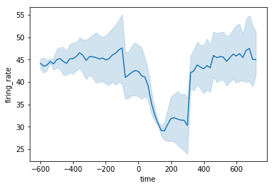

```python
# plot time vs firing_rate
sns.lineplot(x='time', y='firing_rate', data=dots)
```

Now, separate your plot by the `choice` column using color.

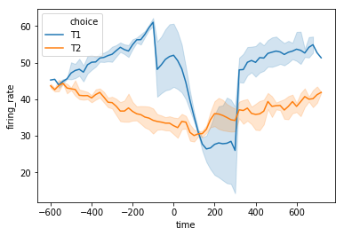

```python
# plot time vs firing_rate separated by choice
sns.lineplot(x='time', y='firing_rate', hue = "choice", data=dots)
```

Next, separate your plot by the `align` column using line style.

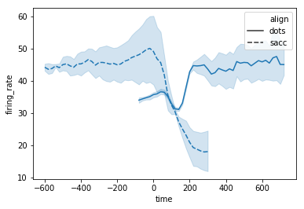

```python
# plot time vs firing_rate separated by align
sns.lineplot(x='time', y='firing_rate', style = "align" ,data=dots)
```

Lastly, combine these two factors to get a plot separated by both `choice` (color) and `align` (style). How many lines do you expect in the resulting graph?

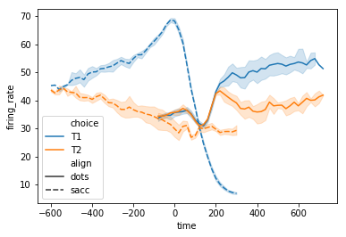

```python
# plot time vs firing_rate separated by choice and align
sns.lineplot(x='time', y='firing_rate', hue = "choice", style = "align" ,data=dots)
```